# Machine Learning on Weight Lifting

Mikael Herve

4/26/2020

# Executive summary

One thing that people regularly do is quantify how much of a particular activity they do, but they rarely quantify how well they do it. In this project, our goal will be to use data from accelerometers on the belt, forearm, arm, and dumbell of 6 participants.

Throughout this document, we are interested in predicting whether some individuals performed exercise properly, and predicting the manner in which they did the exercise, given obtained data from wearable devices.

We will create a report describing how you built your model, how you used cross validation, what you think the expected out of sample error is, and why you made the choices you did. You will also use your prediction model to predict 20 different test cases.

We’ll demonstrate how the use the randomForest method provides the best model in predicting outcome.

# Exploratory phase

Let’s first indicate the reader which packages are loaded within the session

```r
library(dplyr)
```

```r
library(ggplot2)
library(caret)
library(rattle)
library(AppliedPredictiveModeling)
library(corrplot)
library(randomForest)
set.seed(99)

#import data training
download.file("https://d396qusza40orc.cloudfront.net/predmachlearn/pml-training.csv",destfile="C:/Users/mikael.herve/Documents/R/Machine learning/pml_training.csv")
pml_training<-read.csv("C:/Users/mikael.herve/Documents/R/Machine learning/pml_training.csv")

#import data testing
download.file("https://d396qusza40orc.cloudfront.net/predmachlearn/pml-testing.csv",destfile="C:/Users/mikael.herve/Documents/R/Machine learning/pml_testing.csv")
test_cases<-read.csv("C:/Users/mikael.herve/Documents/R/Machine learning/pml_testing.csv")

#split training
inTrain<-createDataPartition(y = pml_training$classe,p = 0.5,list = FALSE)
training<-pml_training[inTrain,]
testing<-pml_training[-inTrain,]

#investigate data (dim, different graphs)
dim(training)
```

```
## [1] 9812  160
```

```r
dim(testing)
```

```
## [1] 9810  160
```

```r
dim(test_cases)
```

```
## [1]  20 160
```

Let’s further explore our data, via View().

First, we need to remove first 7 column, not relevant to exercise. Second, we need to remove columns where lots of NA. Third, we need to eliminate the near zero covariates, i.e. the ones that don’t explain variance.

```r
#clean non releavnt columns
training<-training[,-c(1:7)]
testing<-testing[,-c(1:7)]

#clean nearZeroVariance columsn
nsv<-nearZeroVar(training)
training<-training[,-nsv]
testing<-testing[,-nsv]

#clean N/A
BadValues <- sapply(training, function(x) mean(is.na(x))) > 0.9
training <- training[, BadValues == "FALSE"]
testing<-testing[, BadValues == "FALSE"]

#Ensuring dimensions are consistent in both training and testing
dim(training)
```

```
## [1] 9812   53
```

```r
dim(testing)
```

```
## [1] 9810   53
```

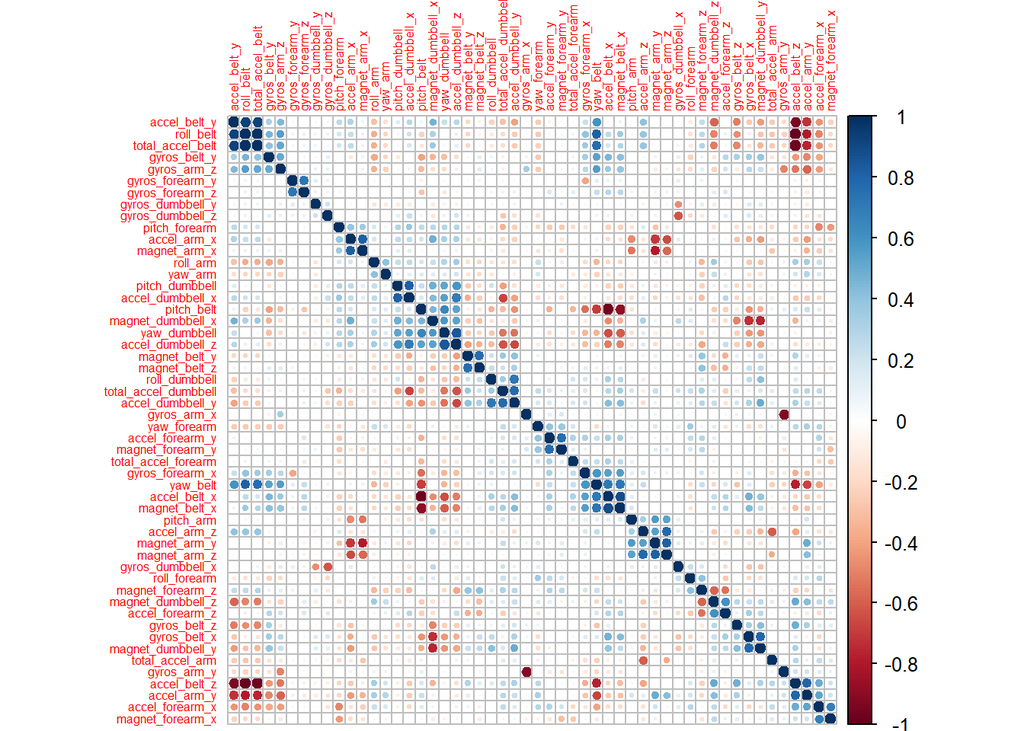

```r
#how are variables correlated.
M<-cor(training[,-53])
corrplot(M,order = "hclust",tl.cex = .5)
```

# Analysis

## rpart and accuracy

We first run a simple tree analysis and measure the accurary of the model on the training and testing set.

```r
set.seed(249)
modFit_rpart<-train(classe~.,data=training,method="rpart")
confusionMatrix(predict(modFit_rpart,training),training$classe)$overall[1]
```

```
##  Accuracy
## 0.5009172
```

```r
confusionMatrix(predict(modFit_rpart,testing),testing$classe)$overall[1]
```

```
##  Accuracy
## 0.4899083
```

We know an approximate .49 accurary number is not optimal and we seek to find another more accurare model.

## rf and accuracy

From the correlation plot, we observe a high degree of correlated variable.  
The next steps we wanted to take was to leverage a random forest model, via the caret package, which we tried first and the machine was not powerful enough to complete. We then seeked to reduce the number of variable from 53 lower, via a pre-processing function such as principal component analysis, and also ran into computing issues.  
We finally found good success in using a random forest model, via the randomForest package.

```r
set.seed(249)
modFit_randomForest<-randomForest(classe~.,data=training)
confusionMatrix(predict(modFit_randomForest,training),training$classe)
```

```
## Confusion Matrix and Statistics
##
##           Reference
## Prediction    A    B    C    D    E
##          A 2790    0    0    0    0
##          B    0 1899    0    0    0
##          C    0    0 1711    0    0
##          D    0    0    0 1608    0
##          E    0    0    0    0 1804
##
## Overall Statistics
##
##                Accuracy : 1
##                  95% CI : (0.9996, 1)
##     No Information Rate : 0.2843
##     P-Value [Acc > NIR] : < 2.2e-16
##
##                   Kappa : 1
##
##  Mcnemar's Test P-Value : NA
##
## Statistics by Class:
##
##                      Class: A Class: B Class: C Class: D Class: E
## Sensitivity            1.0000   1.0000   1.0000   1.0000   1.0000
## Specificity            1.0000   1.0000   1.0000   1.0000   1.0000
## Pos Pred Value         1.0000   1.0000   1.0000   1.0000   1.0000
## Neg Pred Value         1.0000   1.0000   1.0000   1.0000   1.0000
## Prevalence             0.2843   0.1935   0.1744   0.1639   0.1839
## Detection Rate         0.2843   0.1935   0.1744   0.1639   0.1839
## Detection Prevalence   0.2843   0.1935   0.1744   0.1639   0.1839
## Balanced Accuracy      1.0000   1.0000   1.0000   1.0000   1.0000
```

When this model is applied to the test set, we obtained equally satisfying high degree of accurary.

```r
set.seed(249)
confusionMatrix(predict(modFit_randomForest,testing),testing$classe)
```

```
## Confusion Matrix and Statistics
##
##           Reference
## Prediction    A    B    C    D    E
##          A 2785   18    0    0    0
##          B    3 1873   10    0    0
##          C    1    7 1699   24    4
##          D    0    0    2 1580    1
##          E    1    0    0    4 1798
##
## Overall Statistics
##
##                Accuracy : 0.9924
##                  95% CI : (0.9904, 0.994)
##     No Information Rate : 0.2844
##     P-Value [Acc > NIR] : < 2.2e-16
##
##                   Kappa : 0.9903
##
##  Mcnemar's Test P-Value : NA
##
## Statistics by Class:
##
##                      Class: A Class: B Class: C Class: D Class: E
## Sensitivity            0.9982   0.9868   0.9930   0.9826   0.9972
## Specificity            0.9974   0.9984   0.9956   0.9996   0.9994
## Pos Pred Value         0.9936   0.9931   0.9793   0.9981   0.9972
## Neg Pred Value         0.9993   0.9968   0.9985   0.9966   0.9994
## Prevalence             0.2844   0.1935   0.1744   0.1639   0.1838
## Detection Rate         0.2839   0.1909   0.1732   0.1611   0.1833
## Detection Prevalence   0.2857   0.1923   0.1769   0.1614   0.1838
## Balanced Accuracy      0.9978   0.9926   0.9943   0.9911   0.9983
```

We finally display the factor importance of these variables used in the model. Frankly, the level of accurary and computing need look to be satisfactory with the current model. Had we need to fine tun the model, we would use the below graph to select fewer variables and increase number of trees.

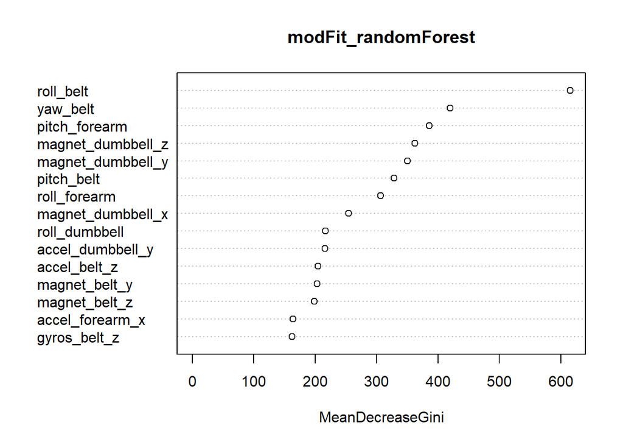

```r
set.seed(249)
varImpPlot(modFit_randomForest,n.var = 15)
```

## Prediction

We finally apply the model fit to the given test cases provided and obtain the following predictions.

```r
prediction<-predict(modFit_randomForest,test_cases)
prediction
```

```
##  1  2  3  4  5  6  7  8  9 10 11 12 13 14 15 16 17 18 19 20
##  B  A  B  A  A  E  D  B  A  A  B  C  B  A  E  E  A  B  B  B
## Levels: A B C D E
```

# Conclusion

We find that the random forest function provides a good balance of quantitative fitting (accuracy, sensitivity and specificity) as well as compute performance and therefore recommended using such model to use for the test cases.